# Taller 2 AAD

Hector Rojas

2023-04-20

```r
options(repos = "http://cran.rstudio.com")
install.packages("mgcv")
install.packages("caret")  # Install the caret package
library(caret)            # Load the caret package
library(ISLR2)
library(boot)
library(splines)
library(mgcv)
library(gam)
library(glmnet)
library(ISLR)
datos<-Auto
datos
```

```
##      mpg cylinders displacement horsepower weight acceleration year origin
## 1   18.0         8        307.0        130   3504         12.0   70      1
## 2   15.0         8        350.0        165   3693         11.5   70      1
## 3   18.0         8        318.0        150   3436         11.0   70      1
## 4   16.0         8        304.0        150   3433         12.0   70      1
## 5   17.0         8        302.0        140   3449         10.5   70      1
## 6   15.0         8        429.0        198   4341         10.0   70      1
## 7   14.0         8        454.0        220   4354          9.0   70      1
## 8   14.0         8        440.0        215   4312          8.5   70      1
## 9   14.0         8        455.0        225   4425         10.0   70      1
## 10  15.0         8        390.0        190   3850          8.5   70      1
## 11  15.0         8        383.0        170   3563         10.0   70      1
## 12  14.0         8        340.0        160   3609          8.0   70      1
## 13  15.0         8        400.0        150   3761          9.5   70      1
## 14  14.0         8        455.0        225   3086         10.0   70      1
```

[output cut: 771 more lines]

```r
# Crear un nuevo data frame con solo las columnas x e y
nueva_data2 <- data.frame(hp = datos$horsepower, mpg = datos$mpg)
nueva_data2
```

```
##      hp  mpg
## 1   130 18.0
## 2   165 15.0
## 3   150 18.0
## 4   150 16.0
## 5   140 17.0
## 6   198 15.0
## 7   220 14.0
## 8   215 14.0
## 9   225 14.0
## 10  190 15.0
## 11  170 15.0
## 12  160 14.0
## 13  150 15.0
## 14  225 14.0
```

[output cut: 378 more lines]

1. **Separe aleatoriamente (pero guarde la semilla) su conjunto de datos en dos partes:**

   **Entrenamiento: 90% de los autos.**

   **Prueba: 10% de los autos.**

```r
# Establecer una semilla para reproducibilidad
set.seed(123)

# Dividir aleatoriamente los datos en conjuntos de entrenamiento y prueba
train_indices_autos <- sample(nrow(nueva_data2), round(0.9 * nrow(nueva_data2)))
train_autos <- nueva_data2[train_indices_autos, ]
test_autos <- nueva_data2[-train_indices_autos, ]

# Imprimir las dimensiones de los conjuntos de datos resultantes
cat("Training dataset dimensions:", dim(train_autos), "\n")
```

```
## Training dataset dimensions: 353 2
```

```r
cat("Testing dataset dimensions:", dim(test_autos), "\n")
```

```
## Testing dataset dimensions: 39 2
```

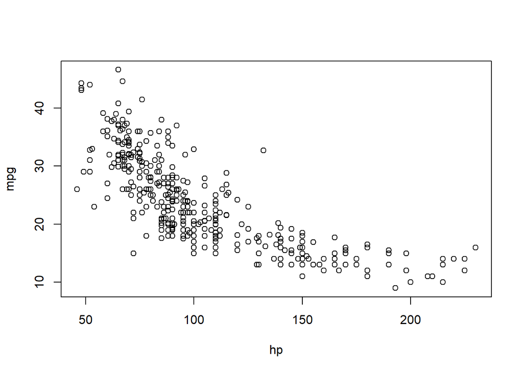

```r
plot(nueva_data2)
```

2. **Usando los datos de entrenamiento Mediante validación cruzada en 10 folds, determine el número óptimo de knots para el problema de regresión spline. Considere como número de posible de knots 1,…,10, igualmente espaciados en el rango de la variable horsepower. ¿Qué modelo (es decir, cual valor de knot con k = 1, …, 10) resulta en un menor ECM de predición?**

```r
# Definir el número de folds para la validación cruzada
k <- 10

# Definir el rango de grados de libertad para el spline natural
df_range_autos <- seq(2, 10, by = 1)

# Dividir los datos en k folds
folds <- createFolds(nueva_data2$hp, k = k)

# Inicializar un vector para almacenar los errores cuadráticos medios
mse <- rep(0, length(df_range_autos))

# Ciclo sobre cada valor de grados de libertad y realizar validación cruzada
for (i in 1:length(df_range_autos)) {
  mse_fold <- rep(0, k)
  for (j in 1:k) {
    # Obtener los datos de entrenamiento y prueba para este fold
    train <- nueva_data2[-folds[[i]], ]
    test <- nueva_data2[folds[[i]], ]
    # Ajustar el modelo utilizando los datos de entrenamiento y evaluar en los datos de prueba
    model <- lm(mpg ~ s(hp, df = df_range_autos[i]), data = train)
    pred <- predict(model, newdata = test)
    mse_fold[j] <- mean((test$mpg  - pred)^2)
  }
  # Promediar los errores cuadráticos medios a través de los folds
  mse[i] <- mean(mse_fold)
}

# Encontrar el número de grados de libertad que minimiza el error cuadrático medio
opt_df <- df_range_autos[which.min(mse)]
mse_opt <- min(mse)

# Imprimir el número óptimo de grados de libertad y el mínimo error cuadrático medio
cat("El número óptimo de grados de libertad es", opt_df, "con un error cuadrático medio mínimo de", mse_opt)
```

```
## El número óptimo de grados de libertad es 4 con un error cuadrático medio mínimo de 15.82202
```

```r
print(mse)
```

```
## [1] 22.30829 21.83144 15.82202 25.76041 28.83821 26.74051 28.20562 22.07160
## [9] 37.67668
```

3. **Usando los datos de entrenamiento, determine el mejor modelo basado en base de funciones Compare el poder de predicción de los modelos: polinomio grado 2 global, spline suavizado y del modelo de regresión spline óptimo (encontrado en el punto anterior) utilizando validación cruzada en 10 folds. ¿Cuál de los tres modelos seleccionaría basado en el ECM de predición?.**

```r
# definiendo el modelo polinomial de grado 2
poly_model <- lm(mpg ~ poly(hp, 2), data = train)
poly_pred <- predict(poly_model, newdata = test)
poly_mse <- mean((test$mpg - poly_pred)^2)
cat("MSE para el modelo pilinomial de grado 2:", poly_mse, "\n")
```

```
## MSE para el modelo pilinomial de grado 2: 33.24663
```

```r
# Modelo Spline smoothing
spline_model <- lm(mpg ~ ns(hp, df = opt_df), data = train)
spline_pred <- predict(spline_model, newdata = test)
spline_mse <- mean((test$mpg - spline_pred)^2)
cat("MSE para Modelo Spline smoothing:", spline_mse, "\n")
```

```
## MSE para Modelo Spline smoothing: 32.36124
```

```r
# Modelo optimal Spline
opt_spline_model <- lm(mpg ~ bs(hp, df = opt_df), data = train)
opt_spline_pred <- predict(opt_spline_model, newdata = test)
opt_spline_mse <- mean((test$mpg - opt_spline_pred)^2)
cat("MSE para modelo optimal Spline:", opt_spline_mse, "\n")
```

```
## MSE para modelo optimal Spline: 32.87085
```

4. **Usando los datos de entrenamiento, determine el mejor modelo basado en regresión local Determine la regresión polinomial local con kernel gaussiano que resulte en menor error de predicción: regresión de grado 0, 1 o 2. Use el ancho de banda óptimo dado por defecto por la función loess().**

```r
# Ajustar modelos de regresión polinomial local de grado 0, 1 y 2
degree0_model <- loess(mpg ~ hp, data = train_autos, degree = 0)
degree1_model <- loess(mpg ~ hp, data = train_autos, degree = 1)
degree2_model <- loess(mpg ~ hp, data = train_autos, degree = 2)

# Predecir usando cada modelo y calcular el error cuadrático medio en el conjunto de prueba
degree0_pred <- predict(degree0_model, newdata = test_autos)
degree1_pred <- predict(degree1_model, newdata = test_autos)
degree2_pred <- predict(degree2_model, newdata = test_autos)

degree0_mse <- mean((test_autos$mpg - degree0_pred)^2)
degree1_mse <- mean((test_autos$mpg - degree1_pred)^2)
degree2_mse <- mean((test_autos$mpg - degree2_pred)^2)

# Determinar el modelo con el menor error cuadrático medio
mse <- c(degree0_mse, degree1_mse, degree2_mse)
opt_degree <- which.min(mse)

# Imprimir el modelo óptimo y su error cuadrático medio
cat("El modelo optimo de regresion polinomial local tiene grado", opt_degree, "con un MSE de", mse[opt_degree], "\n")
```

```
## El modelo optimo de regresion polinomial local tiene grado 3 con un MSE de 21.84482
```

5. **Usando los datos de entrenamiento y de prueba, determine el mejor de los tres paradigmas de modelamiento Ajuste el mejor modelo basado en base de funciones, el mejor modelo basado en regresión local y un polinomio global de grado dos con los datos de entrenamiento y calcule el ECM de prueba para cada modelo.**

```r
cat("MSE para modelo polinomial de grado 2:", poly_mse, "\n")
```

```
## MSE para modelo polinomial de grado 2: 33.24663
```

```r
cat("MSE para modelo optimal spline:", opt_spline_mse, "\n")
```

```
## MSE para modelo optimal spline: 32.87085
```

```r
cat("MSE para modelo spline smoothing:", spline_mse, "\n")
```

```
## MSE para modelo spline smoothing: 32.36124
```

**Repita (1) - (5) un total de 10 veces de manera que en el paso (1) conforme una nueva muestra de validación cruzada, esto le permitirá obtener 10 ECM de prueba para cada paradigma de modelamiento. Grafique las tres distribuciones del ECM de prueba y responda ¿Cuál acercmiento seleccionaría basado en el ECM de predición: basado en base de funciones, basado en regresión local o polinomial global?.**

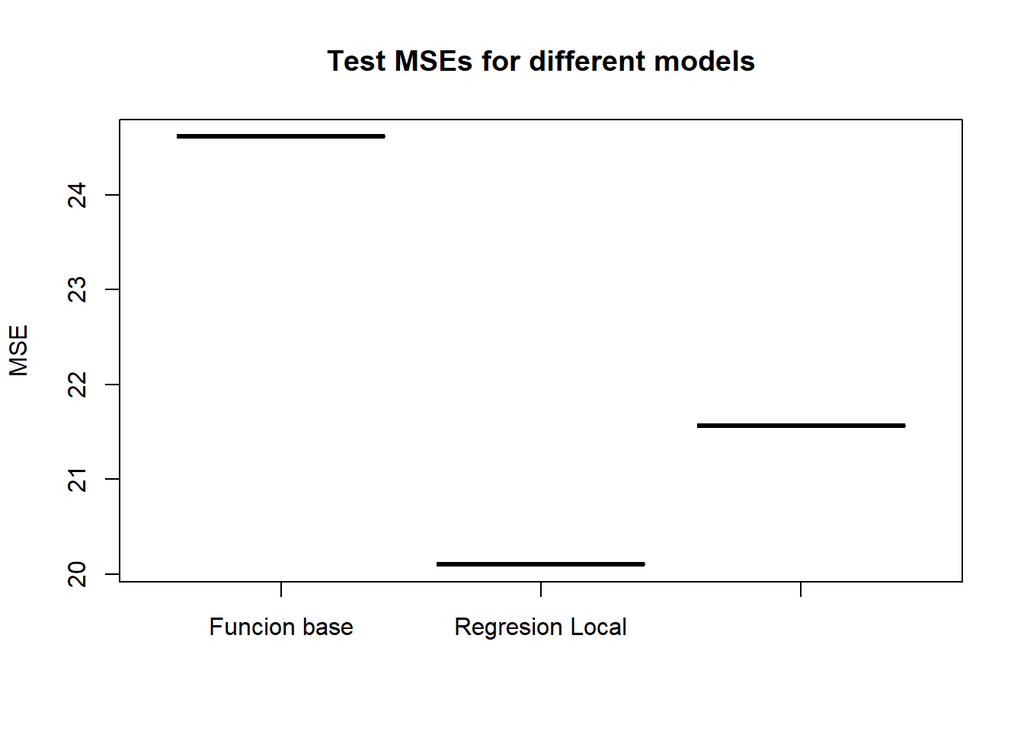

```r
# Crear una función para ajustar y evaluar un modelo usando validación cruzada
  fit_eval_model <- function(model, nueva_data2, k = 10) {
  # Dividir los datos en k folds
  folds <- createFolds(nueva_data2$mpg, k = k)

  # Inicializar un vector para almacenar los errores cuadrados medios
  mse <- rep(0, k)

  # Iterar sobre cada fold y realizar la validación cruzada
  for (i in 1:k) {
    #  Obtener los datos de entrenamiento y prueba para este fold
    train <- unlist(folds[-i])
    test <- folds[[i]]

    # Ajustar el modelo usando los datos de entrenamiento y evaluarlo en los datos de prueba
    model_fit <- model(train)
    pred <- predict(model_fit, newdata = test_autos)
    mse[i] <- mean((test_autos$mpg - pred)^2)
  }

  # Devolver el error cuadratico medio
  return(mean(mse))
}

# Definir los modelos a evaluar
models <- list(
  "Funcion base" = function(data) lm(mpg ~ hp, data = nueva_data2),
  "Regresion Local" = function(data) loess(mpg ~ hp, data = nueva_data2),
  "Regresion polinomial grado 2" = function(data) lm(mpg ~ poly(hp, 2), data = nueva_data2)
)

# Inicializar un vector para almacenar los errores cuadraticos medios en prueba para cada modelo
test_mse <- matrix(NA, nrow = 10, ncol = length(models))

# Iterar 10 veces la validación cruzada y evaluar cada modelo
for (i in 1:10) {
  # Dividir aleatoriamente los datos en conjuntos de entrenamiento y prueba
  train_indices <- sample(nrow(nueva_data2), round(0.9 * nrow(nueva_data2)))
  train_data <- nueva_data2[train_indices, ]
  test_data <- nueva_data2[-train_indices, ]

  # Evaluar cada modelo en los datos de prueba y almacenar los resultados
  for (j in 1:length(models)) {
    test_mse[i, j] <- fit_eval_model(models[[j]], train_data, k = 10)
  }
}

# Crear un boxplot de caja de los errores cuadraticos medios en prueba para cada modelo
boxplot(test_mse, main = "Test MSEs for different models", ylab = "MSE", names = names(models))
```

```r
# Calcular la mediana de los errores cuadraticos medios en prueba para cada modelo
median_mse <- apply(test_mse, 2, median)

# Imprimir la mediana de los errores cuadraticos medios en prueba para cada modelo
cat("Median test MSEs:\n")
```

```
## Median test MSEs:
```

```r
cat(paste0(names(models), ": ", median_mse, "\n"))
```

```
## Funcion base: 24.6110111303127
##  Regresion Local: 20.1029512035014
##  Regresion polinomial grado 2: 21.5644034332912
```

Basado en los acercamiento seleccionamos el modelo basado en regresion local ya que minimiza el MSE